Original Research Article | Protocol B Sole-Author Edition

# Dual In Silico Prioritization of Hepatic CD36 Lipid-Tunnel Modulators (PDB: 5LGD) and Non-Covalent DPP-4 Catalytic Inhibitors (PDB: 4A5S) at Plasma pH 7.4: Strict Quantitative ChEMBL/OpenTargets Gap Analysis, Uniform AutoDock Vina Benchmarking, and Multi-Parameter ADMET Stratification

**Muhammad Abdullah Khan<sup>1*</sup>**  
<sup>1</sup> Department of Pharmaceutics, Faculty of Pharmaceutical Sciences, Government College University Faisalabad (GCUF), Faisalabad 38000, Pakistan  
* Correspondence: abdullah.khan.pharmd@gmail.com | GitHub: https://github.com/abdullah-pharmd/CD36-FFAR4-GLP1-Discovery

### Abstract

Background: Injectable glucagon-like peptide-1 receptor agonists (GLP-1RAs) improve glycemic control and weight in metabolic dysfunction-associated steatotic liver disease (MASLD), yet discontinuation precipitates rapid cardiometabolic rebound. Hepatic fatty acid translocase CD36 accelerates intrahepatic palmitate overload and ACSL4-dependent ferroptosis, whereas vascular dipeptidyl peptidase-4 (DPP-4) cleaves endogenous incretins. An orthogonal small-molecule strategy pairing hepatic CD36 tunnel blockade (PDB: 5LGD) with non-covalent DPP-4 catalytic inhibition (PDB: 4A5S) at plasma pH 7.4 was systematically evaluated across 24 clinical gliptins, hepatoprotective phytochemicals, and native controls.

Methods: Strict single-protein bioactivity curation (pChEMBL ≥ 5.0 [≤ 10 µM] or approved clinical mechanisms) from ChEMBL was intersected against 894 Open Targets disease genes and resolved via two-stage STRING v12.0 network modeling separating pure empirical hubs from hypothesized bridge effectors. Receptors underwent alternate-conformation removal (Val546 altLoc B in 4A5S), physiological pH 7.4 protonation, native crystal redocking (N7F-901 in 4A5S; PLM-512 in 5LGD), uniform AutoDock Vina v1.2.7 screening (exhaustiveness = 8, seed = 42), dual-receptor exhaustiveness = 16 convergence audits, and non-covalent size-matched DPP-4 ROC-AUC validation (N = 60 PubChem BioAssay GeneID:1803 compounds). ADMET gating combined Lipinski/Veber rules, BOILED-Egg permeation with quaternary ammonium efflux correction, Delaney ESOL solubility, PAINS/Brenk alerts, Ligand Efficiency (LE), Lipophilic Ligand Efficiency (LLE), and hydrogen-donor verified 3D pocket interaction analysis.

Results: Empirical curation yielded 125 strict human single-protein targets overlapping 21 disease-linked genes (Efferocytosis hsa04148 FDR = 3.98e-02; GO-BP negative regulation of ROS FDR = 1.40e-04), proving DPP4 engagement by 4 gliptins while confirming zero ChEMBL pChEMBL ≥ 5.0 records for CD36. Native N7F-901 redocked into 4A5S at -10.71 kcal/mol (Hungarian RMSD = 0.780 Å), and exh = 16 convergence deviated by ≤ 0.026 kcal/mol and ≤ 0.079 Å across tested dual-receptor leads. Across N = 60 MW-balanced DPP-4 compounds (p_MW = 0.779), both raw Vina binding energy (ROC-AUC_raw = 0.686, EF20% = 1.83x, Mann–Whitney p = 6.774e-03) and Ligand Efficiency (ROC-AUC_LE = 0.671, EF20%_LE = 1.50x, p = 1.160e-02) achieved statistically significant active-vs-inactive discrimination (p < 0.02) in the MW-balanced druglike space. Multi-parameter tiering prioritized clinical Tier 1A-Gliptins (Linagliptin [DPP-4 -9.81 / CD36 -8.79 kcal/mol]; Sitagliptin [DPP-4 -9.21 / CD36 -8.21 kcal/mol]; Teneligliptin [DPP-4 -8.99 / CD36 -7.37 kcal/mol]), a single PAINS-free oral phytochemical Tier 1A-NP lead (Naringenin: DPP-4 -8.19 kcal/mol [LE = 0.409], CD36 -7.25 kcal/mol [LE = 0.363], 0 PAINS/Brenk, ESOL LogS = -3.49), and portal-hepatic Tier 1B-Cation Berberine (DPP-4 -8.38, CD36 -6.76 kcal/mol), while flagging TPSA > 140 Å² flavonolignans (Silybin A/B -9.98 / -9.90 kcal/mol), catechol-PAINS polyphenols, and sub-LE oligomers (Salvianolic acid B, Lithospermic acid).

Conclusions: This dry-lab triage establishes Teneligliptin, Linagliptin, Sitagliptin, oral Naringenin, and formulation-guided Berberine/Silybin phytosome scaffolds as reproducible computational candidates for dual DPP-4/CD36 modulation, motivating prospective biochemical IC50, SPR/ITC binding, and hepatocyte lipotoxicity verification.

## 1. Introduction

Metabolic dysfunction-associated steatotic liver disease (MASLD) affects over one-quarter of adults globally and progresses rapidly when co-expressed with type 2 diabetes mellitus (T2DM) [1]. Although injectable GLP-1 receptor agonists (GLP-1RAs) achieve marked metabolic and weight reductions in randomized trials [2], post-withdrawal extension analyses demonstrate rapid regain of body weight and cardiometabolic risk upon therapy cessation [3]. These adherence and durability constraints motivate oral or liver-directed small-molecule hypotheses that pair endogenous incretin preservation with upstream intrahepatic lipid-flux attenuation.

Within steatotic hepatocytes, upregulated fatty acid translocase CD36 mediates pathological long-chain palmitate internalization across its 14-Å extracellular lipid tunnel (PDB: 5LGD), feeding ACSL4-catalyzed polyunsaturated phospholipid remodeling and ferroptotic injury [4–6]. Concurrently, circulating endothelial and soluble DPP-4 (PDB: 4A5S) rapidly inactivates gut-derived GLP-1 and GIP by cleaving penultimate N-terminal alanine or proline dipeptides [7,8]. Co-modulating hepatic CD36 lipid translocation alongside catalytic DPP-4 inhibition at systemic plasma pH 7.4 represents a mechanistically complementary strategy for MASLD/T2DM intervention [6–9].

Approved DPP-4 inhibitors span non-covalent triazolopyrazine (Sitagliptin [10]), xanthine (Linagliptin [11]), and Class III S2'-extensive prolylthiazolidine scaffolds (Teneligliptin [9]) alongside covalent cyanopyrrolidine nitriles (Vildagliptin [9]). In parallel, phytochemical scaffolds—including Salvianolic acid B [12], the quaternary isoquinoline alkaloid Berberine subject to P-glycoprotein efflux and portal OCT1 hepatic uptake [13,14], Milk Thistle flavonolignans requiring phosphatidylcholine phytosome formulation [15], and the AMPK-activating flavanone Naringenin [16]—possess documented metabolic literature yet lack unified, uniform-exhaustiveness docking and falsifiable ADMET stratification against crystal CD36 and DPP-4 structures at pH 7.4.

To eliminate optimistic bias, this pure dry-lab investigation enforces four falsifiability safeguards: (i) strict quantitative single-protein ChEMBL curation (pChEMBL ≥ 5.0 or approved mechanism) and separation of pure empirical STRING hubs from unhit mechanistic bridge nodes; (ii) crystallographic alternate-conformation cleaning (Val546 altLoc B removal in 4A5S), plasma pH 7.4 ionization, crystal redocking of both native ligands (N7F-901 in 4A5S and flexible 14-torsion PLM-512 in 5LGD), uniform exhaustiveness = 8 (--seed 42) screening, exhaustiveness = 16 dual-receptor convergence checks, and a size-matched N = 60 non-covalent DPP-4 ROC-AUC benchmark; (iii) strict BOILED-Egg quaternary-cation efflux gating, stereoisomeric SMILES recovery from 3D SDFs, PAINS/Brenk filtering, and Ligand Efficiency thresholding; and (iv) hydrogen-donor-verified 3D polar H-bond classification distinguishing true directional hydrogen bonds from hydrophobic pocket contacts.

## 2. Materials and Methods

**2.1 Live ChEMBL, Open Targets, and Two-Stage STRING v12.0 Network Protocol:** All 24 Protocol B ligands were converted to canonical InChIKeys via RDKit and queried against ChEMBL REST v33 (molecule.json, mechanism.json, and activity.json [17]). Unlike permissive un-unit-filtered queries that conflate percentage inhibition or fold-change readouts with molar affinity, Stage 1 curation strictly required verified human SINGLE PROTEIN targets with standard_units = nM, standard_type in (IC50, EC50, Ki, Kd, AC50), pChEMBL ≥ 5.0 (≤ 10 µM potency), or curated clinical mechanism-of-action annotations. Empirical hits were intersected against 894 unique disease-associated genes compiled from Open Targets Platform GraphQL v4 [18] (MONDO_0011122, MONDO_0005148, EFO_1001248, EFO_1000653). Stage 1 STRING v12.0 interactome and enrichment analyses (required_score = 400, Benjamini–Hochberg FDR < 0.05 [19]) were executed exclusively on the 21 unspiked empirical overlap genes with zero synthetic injections. A separate Stage 2 topological bridge model added pre-specified unhit effectors (ACSL4, CD36, GCG, GLP1R, GPX4) strictly to visualize physical PPI paths to empirical hubs, never to compute unbiased KEGG enrichment.

**2.2 Receptor Structural Preparation, Protonation State, and Uniform Docking:** Cryo/X-ray structures for soluble human CD36 ectodomain (PDB: 5LGD, Chain A, co-crystallized with palmitic acids PLM-512 and PLM-513 [6]) and human DPP-4 (PDB: 4A5S, Chain A, complexed with non-covalent inhibitor N7F-901 [8]) were processed using clean_pdb_strict. All solvent waters, crystallographic solutes, and alternate residue conformations (altLoc not in ' ', 'A', notably removing duplicate Val546 altLoc B coordinates inside the 4A5S S1 pocket) were stripped prior to OpenBabel v3.1.1 Gasteiger assignment and empirical Henderson–Hasselbalch protonation at hepatic/vascular plasma pH 7.4 (-p 7.4 -xr for receptors; -d -p 7.4 for 3D MMFF94s/PubChem ligands). Because OpenBabel applies empirical small-molecule/residue pKa models rather than continuum electrostatic PROPKA calculations, local micro-environmental residue pKa shifts inside buried subpockets remain an explicit computational caveat. Inside 5LGD, crystallographic analysis localized LYS164 NZ near the membrane-proximal tunnel entrance (z = 56.61 Å), whereas native PLM-512 heavy atoms span the central hydrophobic lipid tunnel (z = 26.82–43.83 Å) and PLM-513 occupies the lower exit (z = 8.54–24.51 Å). Docking grids centered strictly on native PLM-512 (22 × 22 × 24 Å) and N7F-901 (22 × 22 × 22 Å) were sampled uniformly across all 24 ligands using AutoDock Vina v1.2.7 (--exhaustiveness 8, --seed 42, Eq. 2) [20,21], storing full docking energy rankings (ΔG_bind, kcal/mol; where the Vina empirical scoring function normalizes intermolecular pairwise Gauss, repulsion, hydrogen-bond, and hydrophobic terms by the rotatable-torsion penalty divisor 1 + w_rot · N_rot):

RMSD<sub>Hungarian</sub> = min<sub>π</sub> √( (1 / N) · Σ ‖ r<sub>i,docked</sub> − r<sub>π(i),crystal</sub> ‖² ) [Eq. 1]

ΔG<sub>bind</sub> = Σ<sub>i<j</sub> [ e<sub>gauss</sub>(d<sub>ij</sub>) + e<sub>rep</sub>(d<sub>ij</sub>) + e<sub>hbond</sub>(d<sub>ij</sub>) + e<sub>hydro</sub>(d<sub>ij</sub>) ] / (1 + w<sub>rot</sub> · N<sub>rot</sub>) [Eq. 2]

LE = −ΔG<sub>bind</sub> / N<sub>heavy</sub> ; LLE = (−ΔG<sub>bind</sub> / 1.364) − cLogP [Eq. 3]

**2.3 Permutation-Invariant Crystal Redocking, Exh = 16 Convergence, and N = 60 Benchmark:** Coordinate fidelity was evaluated via symmetry-corrected bipartite Hungarian heavy-atom RMSD (Eq. 1 [20]) and principal-axis transverse center-of-mass deviation for both 4A5S N7F-901 and native 5LGD PLM-512. To prevent OpenBabel PDB bond-order omission from artificially freezing alkyl torsions (TORSDOF 11 vs. 14 on crystallographic HETATM records), both Table 2 crystal redocking and Table 3 screening used the identical valence-explicit 3D PubChem SDF palmitate representation (CID 985, TORSDOF 14 at pH 7.4) centered on the PLM-512 site. Reproducibility across search depth was audited by re-docking both controls and 6 top leads (Linagliptin, Sitagliptin, Teneligliptin, Naringenin, Berberine, Silybin A) across BOTH receptors at exhaustiveness = 16 (seed = 42). To benchmark scoring power empirically on non-covalent DPP-4 ligands, 30 sub-100 nM actives (IC50/Ki/Kd ≤ 0.1 µM, pChEMBL ≥ 7.0) and 30 size-matched confirmed non-binders (IC50/Ki/Kd ≥ 50 µM or confirmed HTS-inactive never testing active < 15 µM) were retrieved from live PubChem BioAssay (GeneID: 1803, incorporating curated human DPP-4 non-covalent records [22]) after SMARTS exclusion of covalent warheads (-C≡N, boronic acids, epoxides, acrylamides, azides; unpaired t-test p_MW = 0.779). Docked benchmark poses (exh = 8) were quantified via ROC-AUC, 20% enrichment factor (EF20%), and one-sided Mann–Whitney U tests.

**2.4 ADMET Gating, Chemical H-Bond Verification, and Consistent Stratification:** Stereochemical isomeric SMILES were extracted directly from each ligand's 3D SDF to preserve chiral diastereomers (Silybin A vs. Silybin B) and evaluated in RDKit for Lipinski [23], Veber (TPSA ≤ 140 Å², RotB ≤ 10) [24], BOILED-Egg (WLOGP vs. TPSA [25]), Delaney ESOL LogS (reporting mg/mL and µg/mL accurately [26]), PAINS [27], Brenk [28], Ligand Efficiency (LE = −ΔG / N_heavy), and Lipophilic Ligand Efficiency (LLE = −ΔG / 1.364 − cLogP, where 1.364 kcal/mol equals 2.303 RT at 298.15 K [29], Eq. 3). Because permanently charged quaternary ammonium cations ([N+]) violate passive diffusion assumptions due to active P-glycoprotein (ABCB1) intestinal efflux and sinusoidal OCT1 (SLC22A1) portal uptake [13,14], BOILED-Egg classification explicitly flagged quaternary cations as Low (Quat. Cation / P-gp Efflux; Hepatic OCT1) and BBB−. For 3D pose inspection, polar hydrogen bonds (≤ 3.5 Å) strictly required verified PDBQT polar hydrogen (HD) donor-to-acceptor (OA/NA/SA) chemistry coupled with explicit receptor side-chain (sc) or backbone (bb-NH/bb-O) role; donor-lacking contacts were excluded from H-bond counts, and adjacent non-H-bonded contacts (≤ 4.0 Å) explicitly omitted H-bonded residues to prevent cross-column redundancy, while non-bonded heavy-atom pairs < 2.2 Å were flagged as steric clashes. Compounds were stratified consistently across tables, figures, and text using unified quantitative thresholds: Tier 1A required 0 PAINS, Veber Pass, High HIA, DPP-4 ΔG ≤ −8.0 kcal/mol (LE ≥ 0.280), and CD36 ΔG ≤ −7.0 kcal/mol (LE ≥ 0.240); Tier 2A required the same dual-affinity thresholds (DPP-4 ≤ −8.0 and CD36 ≤ −7.0 kcal/mol), 0 PAINS, and MW ≥ 350 Da when exceeding Veber polar surface area (TPSA > 140 Å²), assigning sub-threshold TPSA > 140 Å² compounds (DPP-4 > −8.0) to Tier 2C.

## 3. Results and Discussion

**3.1 Empirical Target Gap and Two-Stage STRING PPI Architecture:** Across 24 curated ligands, strict single-protein ChEMBL queries (pChEMBL ≥ 5.0 or approved mechanism) identified 125 unique human targets, of which 21 overlapped the 894-gene Open Targets MASLD/T2DM/obesity disease universe (CD36 exhibited 0 strict empirical hits; DPP4 was empirically confirmed via Linagliptin, Sitagliptin, Teneligliptin, Vildagliptin). Unspiked Stage 1 STRING v12.0 clustering of these 21 empirical genes (Figure 1A, Table 1) formed 44 interactions across 16 connected proteins (5 singletons: CA4, DRD4, ENPP1, GAA, SHBG), anchored by TP53 [degree = 12, betweenness = 0.1432], HIF1A [degree = 11, betweenness = 0.1287], EGFR [degree = 10, betweenness = 0.0566], PPARA [degree = 9, betweenness = 0.0322], NOX4 [degree = 8, betweenness = 0.0291], CASP1 [degree = 7, betweenness = 0.0076], XDH [degree = 6, betweenness = 0.0583], HDAC9 [degree = 4, betweenness = 0.0000]. Unbiased Stage 1 enrichment (synchronized identically across Figure 1B and Table 1) recovered all 9 significant KEGG terms (FDR < 0.05)—including Efferocytosis (hsa04148, FDR = 3.98e-02), Starch and sucrose metabolism (hsa00500, FDR = 3.98e-02), and Hepatitis C hepatic injury (hsa05160, FDR = 3.98e-02)—alongside 5 targeted metabolic/redox GO Biological Processes led by negative regulation of ROS (GO:2000378, FDR = 1.40e-04) and glucose metabolic process (GO:0006006, FDR = 3.70e-03). Note that oncology/viral KEGG entries (Bladder cancer, Pathways in cancer, MicroRNAs in cancer, Proteoglycans in cancer, Central carbon metabolism in cancer) arise from pleiotropic KEGG/STRING indexing of TP53, EGFR, and HIF1A within unweighted 21-gene overlap sets and are not interpreted as tumorigenic signals. Critically, because CD36, ACSL4, GPX4, GCG, and GLP1R exhibited zero strict empirical ChEMBL hits among these compounds, Stage 2 topological bridging (Figure 1C) appended those 5 mechanistic effectors strictly as a connectivity map (73 total edges across 22/26 connected nodes), demonstrating physical STRING links between unhit CD36 and empirical metabolic regulators (PPARA, PPARD, HIF1A, DPP4) without contaminating Stage 1 pathway statistics.

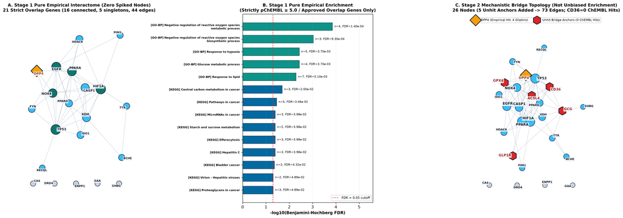

Figure 1. Live ChEMBL–OpenTargets–STRING v12.0 network analysis separating pure Stage 1 empirical hubs and enrichment from Stage 2 mechanistic bridge connectivity.

**Table 1. Stage 1 Pure Empirical Hub Centrality and Synchronized KEGG (All 9) / Metabolic GO-BP (5 Terms) Enrichment**

| Dataset / Analysis | Identifier / Symbol | Metric Summary (Degree / Term) | Empirical Stats (Betweenness / FDR) | Empirical Mapped Genes |
| --- | --- | --- | --- | --- |
| Empirical Hub (Stage 1) | TP53 | Degree = 12; Closeness = 0.625 | Btw = 0.1432; Eig = 0.4007 | Strict pChEMBL ≥ 5.0 ∩ OpenTargets |
| Empirical Hub (Stage 1) | HIF1A | Degree = 11; Closeness = 0.592 | Btw = 0.1287; Eig = 0.3775 | Strict pChEMBL ≥ 5.0 ∩ OpenTargets |
| Empirical Hub (Stage 1) | EGFR | Degree = 10; Closeness = 0.536 | Btw = 0.0566; Eig = 0.3587 | Strict pChEMBL ≥ 5.0 ∩ OpenTargets |
| Empirical Hub (Stage 1) | PPARA | Degree = 9; Closeness = 0.536 | Btw = 0.0322; Eig = 0.3523 | Strict pChEMBL ≥ 5.0 ∩ OpenTargets |
| Empirical Hub (Stage 1) | NOX4 | Degree = 8; Closeness = 0.511 | Btw = 0.0291; Eig = 0.3209 | Strict pChEMBL ≥ 5.0 ∩ OpenTargets |
| Empirical Hub (Stage 1) | CASP1 | Degree = 7; Closeness = 0.489 | Btw = 0.0076; Eig = 0.3092 | Strict pChEMBL ≥ 5.0 ∩ OpenTargets |
| Empirical Hub (Stage 1) | XDH | Degree = 6; Closeness = 0.469 | Btw = 0.0583; Eig = 0.2471 | Strict pChEMBL ≥ 5.0 ∩ OpenTargets |
| Empirical Hub (Stage 1) | HDAC9 | Degree = 4; Closeness = 0.417 | Btw = 0.0000; Eig = 0.2042 | Strict pChEMBL ≥ 5.0 ∩ OpenTargets |
| Empirical Hub (Stage 1) | IDO1 | Degree = 4; Closeness = 0.417 | Btw = 0.0000; Eig = 0.1983 | Strict pChEMBL ≥ 5.0 ∩ OpenTargets |
| Empirical Hub (Stage 1) | PPARD | Degree = 4; Closeness = 0.417 | Btw = 0.0000; Eig = 0.2042 | Strict pChEMBL ≥ 5.0 ∩ OpenTargets |
| Empirical Hub (Stage 1) | DPP4 | Degree = 3; Closeness = 0.375 | Btw = 0.0000; Eig = 0.1472 | Strict pChEMBL ≥ 5.0 ∩ OpenTargets |
| Empirical KEGG (FDR < 0.05) | hsa05230 | Central carbon metabolism in cancer | n = 3; FDR = 2.00e-02 | TP53,EGFR,HIF1A |
| Empirical KEGG (FDR < 0.05) | hsa05200 | Pathways in cancer | n = 5; FDR = 3.46e-02 | TP53,EGFR,PPARD,PIM1,HIF1A |
| Empirical KEGG (FDR < 0.05) | hsa00500 | Starch and sucrose metabolism | n = 2; FDR = 3.98e-02 | GAA,ENPP1 |
| Empirical KEGG (FDR < 0.05) | hsa04148 | Efferocytosis | n = 3; FDR = 3.98e-02 | PPARD,CASP1,HIF1A |
| Empirical KEGG (FDR < 0.05) | hsa05160 | Hepatitis C | n = 3; FDR = 3.98e-02 | TP53,EGFR,PPARA |
| Empirical KEGG (FDR < 0.05) | hsa05206 | MicroRNAs in cancer | n = 3; FDR = 3.98e-02 | TP53,EGFR,PIM1 |
| Empirical KEGG (FDR < 0.05) | hsa05219 | Bladder cancer | n = 2; FDR = 4.32e-02 | TP53,EGFR |
| Empirical KEGG (FDR < 0.05) | hsa03272 | Virion - Hepatitis viruses | n = 2; FDR = 4.89e-02 | EGFR,DPP4 |
| Empirical KEGG (FDR < 0.05) | hsa05205 | Proteoglycans in cancer | n = 3; FDR = 4.89e-02 | TP53,EGFR,HIF1A |
| Empirical GO-BP (FDR < 0.01) | GO:2000378 | Negative regulation of reactive oxygen species metabolic process | n = 4; FDR = 1.40e-04 | TP53,FYN,PPARA,HIF1A |
| Empirical GO-BP (FDR < 0.01) | GO:1903427 | Negative regulation of reactive oxygen species biosynthetic process | n = 3; FDR = 9.30e-04 | FYN,PPARA,HIF1A |
| Empirical GO-BP (FDR < 0.01) | GO:0001666 | Response to hypoxia | n = 5; FDR = 3.70e-03 | TP53,PPARD,DPP4,PPARA,HIF1A |
| Empirical GO-BP (FDR < 0.01) | GO:0006006 | Glucose metabolic process | n = 4; FDR = 3.70e-03 | TP53,GAA,PPARD,PPARA |
| Empirical GO-BP (FDR < 0.01) | GO:0033993 | Response to lipid | n = 7; FDR = 5.10e-03 | BCHE,EGFR,PPARD,PIM1,PPARA,IDO1,CASP1 |

**3.2 Redocking, Convergence Depth, and Size-Matched N = 60 Benchmarking:** Protocol B receptor preparation and sampling reliability met strict geometric benchmarks (Table 2). In DPP-4 (4A5S), native non-covalent inhibitor N7F-901 redocked at ΔG = -10.71 kcal/mol with permutation-invariant Hungarian heavy-atom RMSD = 0.780 Å and center-of-mass shift 0.329 Å (Eq. 1), reproducing experimental S1/S2 polar anchoring (GLU206 (2.76 Å, sc), GLU205 (2.80 Å, sc), TYR662 (2.88 Å, sc), TYR631 (3.17 Å, bb-NH)). In soluble CD36 (5LGD), unified valence-explicit palmitate (PLM-512 / CID 985, TORSDOF 14) scored an identical ΔG = -6.13 kcal/mol in both Table 2 and Table 3 with Hungarian RMSD = 3.098 Å and perpendicular transverse tunnel-axis deviation = 0.156 Å (XY radial = 1.104 Å; exh = 16 energy shift 0.102 kcal/mol, longitudinal head-to-tail flip RMSD = 8.281 Å), proving sub-Angstrom radial alignment along the symmetric hydrophobic tunnel axis (z = 26.8–43.8 Å) despite flat axial translation. Crucially, raising search depth from uniform exhaustiveness = 8 to exhaustiveness = 16 across both 5LGD and 4A5S for crystal N7F-901 and all 6 tested drug/phytochemical leads (Linagliptin, Sitagliptin, Teneligliptin, Naringenin, Berberine, Silybin A) produced maximal |ΔΔG| ≤ 0.026 kcal/mol and maximal pose drift ≤ 0.079 Å (Table 2). Against N = 60 size-matched non-covalent DPP-4 ligands (Mean Active MW = 353.5 Da vs. Inactive MW = 355.5 Da, p_MW = 0.779; Figure 2), both raw Vina binding energy (ROC-AUC_raw = 0.686, EF20% = 1.83x, Mann–Whitney p = 6.774e-03) and Ligand Efficiency (ROC-AUC_LE = 0.671, EF20%_LE = 1.50x, p = 1.160e-02) achieved statistically significant active-vs-inactive discrimination (p < 0.02) in the MW-balanced druglike space. Combined with strict LE ≥ 0.280 gating, this prevents high-MW macro-oligomers (MW > 500 Da) from biasing raw affinity rankings.

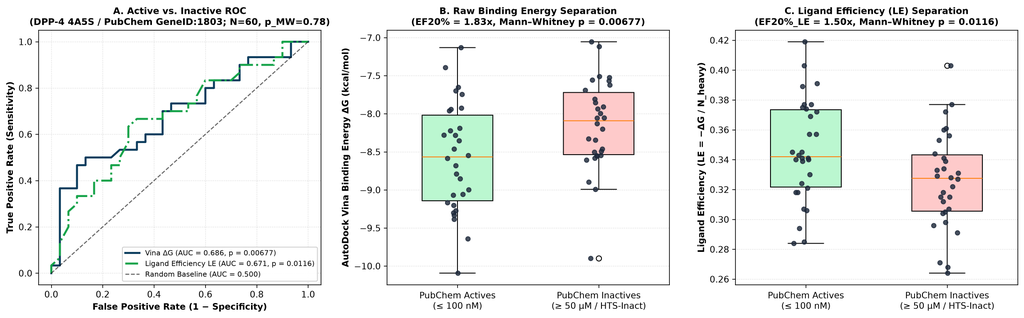

Figure 2. Size-matched N = 60 non-covalent DPP-4 (4A5S, pH 7.4, exh = 8) PubChem BioAssay (GeneID: 1803) empirical ROC-AUC validation.

**Table 2. Native Crystal Hungarian Heavy-Atom Redocking and Dual-Receptor Convergence Audit (exh = 8 vs. 16)**

| Compound / Control | Receptor Target | Crystal RMSD (Å) | Transverse / CoM Err (Å) | Exh = 8 ΔG (kcal/mol) | Exh = 16 ΔG (kcal/mol) | \|ΔΔG\| (kcal/mol) | Exh 8 vs 16 Drift RMSD (Å) |
| --- | --- | --- | --- | --- | --- | --- | --- |
| N7F-901 (Native Crystal) | DPP-4 (4A5S) | 0.780 | 0.329 | -10.71 | -10.71 | 0.000 | 0.000 |
| PLM-512 (Palmitic acid CID 985) | CD36 (5LGD) | 3.098 | 0.156 | -6.13 | -6.23 | 0.102 | 8.281 |
| Sitagliptin | CD36 (5LGD) | — | — | -8.21 | -8.21 | 0.000 | 0.000 |
| Sitagliptin | DPP-4 (4A5S) | — | — | -9.21 | -9.23 | 0.026 | 0.042 |
| Linagliptin | CD36 (5LGD) | — | — | -8.79 | -8.79 | 0.000 | 0.000 |
| Linagliptin | DPP-4 (4A5S) | — | — | -9.81 | -9.81 | 0.000 | 0.000 |
| Silybin A | CD36 (5LGD) | — | — | -7.57 | -7.57 | 0.000 | 0.000 |
| Silybin A | DPP-4 (4A5S) | — | — | -9.98 | -9.98 | 0.000 | 0.000 |
| Naringenin | CD36 (5LGD) | — | — | -7.25 | -7.26 | 0.010 | 0.012 |
| Naringenin | DPP-4 (4A5S) | — | — | -8.19 | -8.19 | 0.000 | 0.000 |
| Berberine | CD36 (5LGD) | — | — | -6.76 | -6.74 | 0.020 | 0.048 |
| Berberine | DPP-4 (4A5S) | — | — | -8.38 | -8.36 | 0.026 | 0.075 |
| Teneligliptin | CD36 (5LGD) | — | — | -7.37 | -7.37 | 0.000 | 0.000 |
| Teneligliptin | DPP-4 (4A5S) | — | — | -8.99 | -9.00 | 0.010 | 0.079 |

**3.3 Integrated Dual-Receptor Stratification and ADMET Triage:** Applying unified Tier 1A gates (0 PAINS, Veber Pass, High HIA, DPP-4 ≤ −8.0 kcal/mol [LE ≥ 0.280], CD36 ≤ −7.0 kcal/mol [LE ≥ 0.240]; Eq. 3, Figures 3–4, Table 3) sharply separated deployable leads from promiscuous or poorly permeable scaffolds across all 24 compounds. Three non-covalent clinical gliptins satisfied Tier 1A-Gliptin criteria (Linagliptin [DPP-4 -9.81 / CD36 -8.79 kcal/mol]; Sitagliptin [DPP-4 -9.21 / CD36 -8.21 kcal/mol]; Teneligliptin [DPP-4 -8.99 / CD36 -7.37 kcal/mol]), led in dual score rank by Linagliptin (#1), Sitagliptin (#2), and Teneligliptin (#3, Class III S2'-extensive motif [9], DPP-4 LE = 0.300). Among phytochemicals, **Naringenin** (#4 overall rank) emerged as the sole Tier 1A-NP oral lead (DPP-4 ΔG = -8.19 kcal/mol, LE = 0.409; CD36 ΔG = -7.25 kcal/mol, LE = 0.363; 0 PAINS, 0 Brenk, 0 Lipinski violations), supporting its reported AMPK/MASLD activity [16]. **Berberine** occupied Tier 1B-Cation (DPP-4 ΔG = -8.38 kcal/mol, LE = 0.335; CD36 ΔG = -6.76 kcal/mol, LE = 0.270), while strictly four stereochemically resolved Milk Thistle flavonolignans—Silybin A (DPP-4 -9.98, CD36 -7.57), Silybin B (DPP-4 -9.90, CD36 -7.64), Silychristin, and Isosilybin A—satisfied both dual-affinity gates inside Figure 4A (DPP-4 ≤ −9.25, CD36 ≤ −7.53 kcal/mol) yet fell into Tier 2A (0 PAINS, TPSA > 140 Å²) requiring phosphatidylcholine phytosome delivery [15]. Glycosylated Fraxin (TPSA = 159.1 Å², DPP-4 = -7.47 kcal/mol) fell outside the -8.0 kcal/mol DPP-4 gate and was assigned consistently to Tier 2C alongside low-MW coumarin/cinnamate fragments (Scopoletin, Esculetin, Umbelliferone, Ferulic acid, LE_DPP4 up to 0.532). Catechol-PAINS polyphenols split strictly by Veber compliance into Tier 1C-PAINS (Luteolin, Quercetin, TPSA ≤ 131.4 Å²) vs. Tier 2B (Rosmarinic acid, Chlorogenic acid, Salvianolic acid A, Chicoric acid, all failing both Veber TPSA > 140 Å² and catechol PAINS), whereas macro-oligomers Salvianolic acid B (MW = 718.6 Da, LE_DPP4 = 0.178) and Lithospermic acid (MW = 538.5 Da, LE_DPP4 = 0.229) were disqualified (LE < 0.250). Covalent control Vildagliptin (-C≡N nitrile [9], non-covalent ΔG_DPP4 = -7.80) alongside unified native Palmitic acid (5LGD ΔG_CD36 = -6.13) served strictly as mechanistic controls.

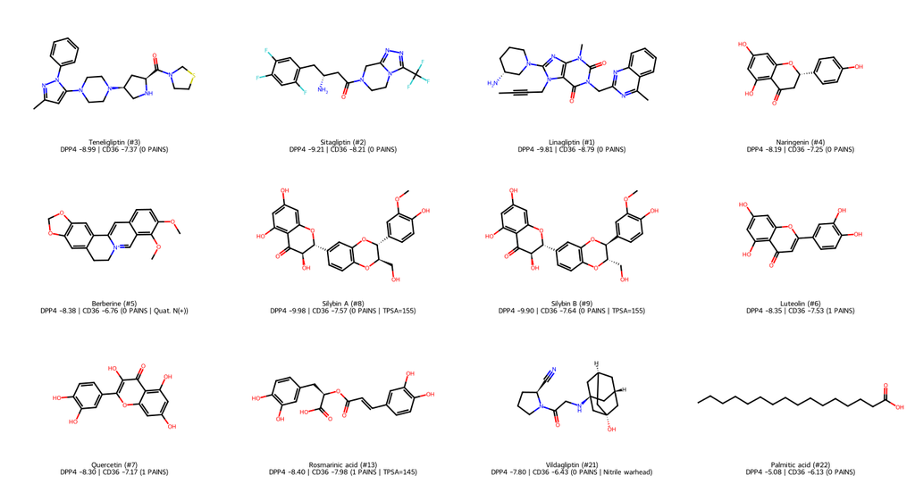

Figure 3. Stereochemically resolved 2D structures, ranks, affinities, and structural-alert badges.

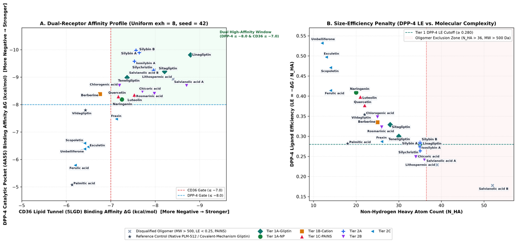

Figure 4. Dual-target affinity scatter aligned with Tier 1A gates and Ligand Efficiency size-penalty stratification (rose-shaded Oligomer Exclusion Zone strictly denotes N_HA > 36 / MW > 500 Da, leaving Salvianolic acid A [N_HA = 36, MW = 494.4 Da] in Tier 2B).

**Table 3. Master Physicochemical, BOILED-Egg, ESOL LogS, PAINS/Brenk, Dual Docking, and Tier Matrix (n = 24)**

| # | Compound | MW | N_HA | TPSA | HIA | LogS | PAINS | Brenk | CD36 | LE_C | DPP4 | LE_D | LLE | Dual | Tier |
| --- | --- | --- | --- | --- | --- | --- | --- | --- | --- | --- | --- | --- | --- | --- | --- |
| 1 | Linagliptin | 472.6 | 35 | 116.9 | High | -3.63 | 0 | 1 | -8.79 | 0.251 | -9.81 | 0.280 | 6.04 | -9.30 | Tier 1A-Gliptin |
| 2 | Sitagliptin | 407.3 | 28 | 77.0 | High | -3.66 | 0 | 1 | -8.21 | 0.293 | -9.21 | 0.329 | 4.73 | -8.71 | Tier 1A-Gliptin |
| 3 | Teneligliptin | 426.6 | 30 | 56.6 | High | -3.48 | 0 | 0 | -7.37 | 0.246 | -8.99 | 0.300 | 5.02 | -8.18 | Tier 1A-Gliptin |
| 4 | Naringenin | 272.3 | 20 | 87.0 | High | -3.49 | 0 | 0 | -7.25 | 0.363 | -8.19 | 0.409 | 3.49 | -7.72 | Tier 1A-NP |
| 5 | Berberine | 336.4 | 25 | 40.8 | Low(Quat/Pgp) | -4.22 | 0 | 1 | -6.76 | 0.270 | -8.38 | 0.335 | 3.05 | -7.57 | Tier 1B-Cation |
| 6 | Luteolin | 286.2 | 21 | 111.1 | High | -3.55 | 1(Cat) | 1 | -7.53 | 0.359 | -8.35 | 0.398 | 3.84 | -7.94 | Tier 1C-PAINS |
| 7 | Quercetin | 302.2 | 22 | 131.4 | High | -3.44 | 1(Cat) | 1 | -7.17 | 0.326 | -8.30 | 0.377 | 4.09 | -7.73 | Tier 1C-PAINS |
| 8 | Silybin A | 482.4 | 35 | 155.1 | Low | -4.43 | 0 | 0 | -7.57 | 0.216 | -9.98 | 0.285 | 4.95 | -8.77 | Tier 2A |
| 9 | Silybin B | 482.4 | 35 | 155.1 | Low | -4.43 | 0 | 0 | -7.64 | 0.218 | -9.90 | 0.283 | 4.90 | -8.77 | Tier 2A |
| 10 | Silychristin | 482.4 | 35 | 166.1 | Low | -4.46 | 0 | 0 | -7.96 | 0.227 | -9.25 | 0.264 | 4.38 | -8.61 | Tier 2A |
| 11 | Isosilybin A | 482.4 | 35 | 155.1 | Low | -4.43 | 0 | 0 | -7.53 | 0.215 | -9.58 | 0.274 | 4.66 | -8.55 | Tier 2A |
| 12 | Salvianolic acid A | 494.4 | 36 | 185.0 | Low | -4.85 | 1(Cat) | 3 | -8.70 | 0.242 | -8.70 | 0.242 | 3.04 | -8.70 | Tier 2B |
| 13 | Rosmarinic acid | 360.3 | 26 | 144.5 | Low | -3.13 | 1(Cat) | 2 | -7.98 | 0.307 | -8.40 | 0.323 | 4.40 | -8.19 | Tier 2B |
| 14 | Chicoric acid | 474.4 | 34 | 208.1 | Low | -3.22 | 1(Cat) | 2 | -7.71 | 0.227 | -8.47 | 0.249 | 4.98 | -8.09 | Tier 2B |
| 15 | Chlorogenic acid | 354.3 | 25 | 164.8 | Low | -1.54 | 1(Cat) | 2 | -7.20 | 0.288 | -8.70 | 0.348 | 7.03 | -7.95 | Tier 2B |
| 16 | Scopoletin | 192.2 | 14 | 59.7 | High | -2.45 | 0 | 1 | -6.41 | 0.458 | -6.59 | 0.471 | 3.33 | -6.50 | Tier 2C |
| 17 | Esculetin | 178.1 | 13 | 70.7 | High | -2.27 | 1(Cat) | 2 | -6.49 | 0.499 | -6.46 | 0.497 | 3.54 | -6.48 | Tier 2C |
| 18 | Umbelliferone | 162.1 | 12 | 50.4 | High | -2.41 | 0 | 1 | -6.41 | 0.534 | -6.39 | 0.532 | 3.18 | -6.40 | Tier 2C |
| 19 | Ferulic acid | 194.2 | 14 | 66.8 | High | -2.11 | 0 | 1 | -6.20 | 0.443 | -5.79 | 0.414 | 2.74 | -6.00 | Tier 2C |
| 20 | Fraxin | 370.3 | 26 | 159.1 | Low | -1.33 | 0 | 1 | -7.13 | 0.274 | -7.47 | 0.287 | 6.79 | -7.30 | Tier 2C |
| 21 | Vildagliptin | 303.4 | 22 | 76.4 | High | -2.26 | 0 | 0 | -6.43 | 0.292 | -7.80 | 0.354 | 4.55 | -7.11 | Ref Control |
| 22 | Palmitic acid | 256.4 | 18 | 37.3 | High | -4.00 | 0 | 1 | -6.13 | 0.341 | -5.08 | 0.282 | -1.83 | -5.61 | Ref Control |
| 23 | Lithospermic acid | 538.5 | 39 | 211.3 | Low | -4.74 | 1(Cat) | 2 | -8.40 | 0.215 | -8.93 | 0.229 | 3.77 | -8.66 | Disq Oligomer |
| 24 | Salvianolic acid B | 718.6 | 52 | 278.0 | Low | -5.94 | 1(Cat) | 2 | -7.98 | 0.154 | -9.26 | 0.178 | 3.46 | -8.62 | Disq Oligomer |

**3.4 BOILED-Egg Space, Quaternary-Cation Pharmacokinetics, and ESOL Solubility:** Simultaneous BOILED-Egg and ESOL LogS mapping (Figure 5, Table 3) exposed two critical pharmacokinetic boundaries obscured by naive atom-count heuristics. First, because permanently charged quaternary nitrogen [N+] species undergo active intestinal P-glycoprotein (ABCB1) efflux and active hepatic uptake via sinusoidal OCT1 (SLC22A1) [13,14], **Berberine** (WLOGP = 3.10, TPSA = 40.8 Å²) was excluded from passive HIA+/BBB+ ellipses and assigned portal-hepatic Tier 1B-Cation priority—consistent with first-pass hepatic accumulation despite low systemic oral bioavailability [14]. Second, **Naringenin** combines an aqueous Delaney ESOL LogS = -3.49 (0.088 mg/mL, or 88.1 µg/mL) with positive DPP-4 LLE = 3.49 (CD36 LLE = 2.81), whereas Silybin A/B, Isosilybin A, and Silychristin sit outside the Veber TPSA ≤ 140 Å² boundary (155.1–166.1 Å²), corroborating clinical trials requiring lipid–phosphatidylcholine complexation to overcome poor passive permeation [15].

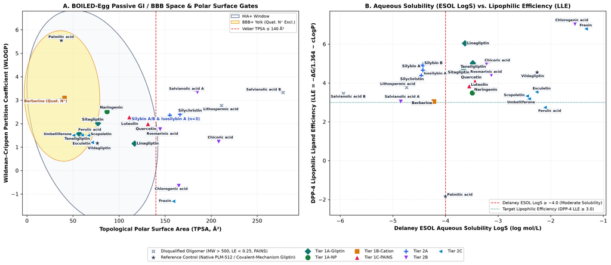

Figure 5. BOILED-Egg GI/BBB space with quaternary cation override and Delaney ESOL LogS vs. DPP-4 LLE.

**3.5 Coordinate-Resolved 3D Pocket Interactions and CD36 Tunnel Depth Profile:** Donor-verified 3D interaction auditing (HD-confirmed ≤ 3.5 Å H-bonds separated strictly from non-H-bonded additional hydrophobic/vdW pocket contacts ≤ 4.0 Å; Figure 6, Table 4) confirmed authentic subsite engagement across both receptors with zero severe < 2.2 Å steric clashes for all Tier 1A/1B leads. Inside DPP-4 (4A5S; Figure 6A–B), Teneligliptin (ΔG = -8.99) spans the S1/S2/S2'-extensive pocket (TYR631 (3.39 Å, bb-NH)), Naringenin (ΔG = -8.19) forms verified H-bonds (GLU206 (2.85 Å, bb-O), SER209 (2.89 Å, sc), ARG669 (3.13 Å, sc), TYR631 (3.17 Å, bb-NH), PHE357 (3.31 Å, bb-O)) alongside hydrophobic TYR666 (3.31 Å), TYR662 (3.34 Å), TYR547 (3.42 Å), ARG358 (3.68 Å), GLU205 (3.78 Å) contacts, and Berberine (zero ligand H-bond donors, HBD = 0) acts strictly as an H-bond acceptor via its dioxole/methoxy oxygens receiving from receptor side-chain hydroxyl donors (TYR752 (2.84 Å, sc), TYR547 (3.43 Å, sc)) alongside TRP629 (3.36 Å), SER630 (3.38 Å), HIS748 (3.50 Å), GLY741 (3.67 Å) aromatic packing without spurious O···O artifacts. Inside soluble CD36 (5LGD; Figure 6C–D), axial coordinate profiling places LYS164 NZ at the outer ectodomain mouth (z = 56.61 Å) ~12.8 Å above crystallographic PLM-512 (z = 26.82–43.83 Å). Rather than clustering at one uniform locus, top leads occupy **complementary adjacent segments** of the PLM-512 translocation corridor around shared pivot GLU335: **Naringenin** fills the upper chamber (z = 39.7–44.9 Å; ALA141 (2.77 Å, bb-O), ARG337 (2.80 Å, sc), ALA145 (3.01 Å, bb-NH), THR195 (3.44 Å, sc) plus TYR149 (3.40 Å), ALA144 (3.45 Å), GLU335 (3.49 Å), ILE148 (3.51 Å), LEU187 (3.57 Å), VAL198 (3.68 Å), matching the carboxylate headgroup envelope of palmitate), whereas **Linagliptin** (z = 24.1–32.3 Å; SER269 (3.47 Å, sc) plus LYS334 (3.30 Å), TYR202 (3.37 Å), GLU335 (3.38 Å), PRO203 (3.39 Å), PHE201 (3.40 Å), ASP270 (3.45 Å), ILE341 (3.48 Å)) and **Teneligliptin** (z = 24.3–32.7 Å; SER269 (2.95 Å, bb-O), TYR238 (2.98 Å, sc) plus CYS333 (3.37 Å), GLU335 (3.37 Å), ASP270 (3.47 Å), LYS334 (3.47 Å), PRO203 (3.49 Å), TYR204 (3.54 Å), ARG63 (3.58 Å)) span the deeper mid-tunnel acyl chamber (PRO203, SER269, LYS334, GLU335), advancing a testable steric blockade hypothesis across adjacent segments of the fatty-acid channel.

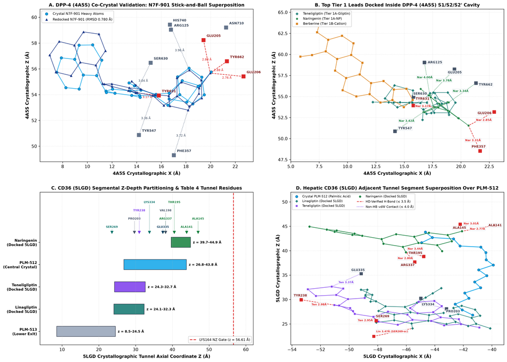

Figure 6. 3D coordinate-derived stick-and-ball binding geometry across 4A5S DPP-4 and 5LGD CD36 segmental Z-depth profiles (red dashed = HD-verified H-bonds ≤ 3.5 Å, incl. Linagliptin SER269 [3.47 Å]; dotted = non-HB vdW contacts ≤ 4.0 Å).

**Table 4. Hydrogen-Donor Verified 3D Polar H-Bonds (≤ 3.5 Å), Additional Non-H-Bonded Contacts (≤ 4.0 Å), and Steric Clashes (< 2.2 Å)**

| Compound | Tier | CD36 HD-Verified H-Bonds (≤ 3.5 Å) | CD36 Additional Non-HB Contacts (≤ 4.0 Å) / Clashes | DPP-4 HD-Verified H-Bonds (≤ 3.5 Å) | DPP-4 Additional Non-HB Contacts (≤ 4.0 Å) / Clashes |
| --- | --- | --- | --- | --- | --- |
| Linagliptin | Tier 1A-Gliptin | SER269 (3.47 Å, sc) | LYS334 (3.30 Å), TYR202 (3.37 Å), GLU335 (3.38 Å), PRO203 (3.39 Å), PHE201 (3.40 Å), ASP270 (3.45 Å), ILE341 (3.48 Å) [Clash: 0] | ASP545 (2.96 Å, sc), ARG125 (3.02 Å, sc), TYR547 (3.38 Å, sc) | TYR666 (2.63 Å), TRP629 (3.26 Å), GLY628 (3.37 Å), SER630 (3.41 Å), TYR662 (3.46 Å), VAL711 (3.46 Å), VAL656 (3.52 Å) [Clash: 0] |
| Sitagliptin | Tier 1A-Gliptin | LEU200 (3.15 Å, bb-O), TYR230 (3.15 Å, sc), SER269 (3.23 Å, sc), LYS334 (3.34 Å, sc) | LEU416 (3.09 Å), LEU387 (3.18 Å), ASP209 (3.28 Å), CYS272 (3.38 Å), PHE201 (3.47 Å), TYR238 (3.54 Å), ASP270 (3.59 Å) [Clash: 0] | TYR662 (2.98 Å, sc), SER630 (3.00 Å, sc), TRP629 (3.28 Å, bb-O), ARG125 (3.47 Å, sc), HIS740 (3.49 Å, sc) | TYR752 (3.15 Å), TYR631 (3.27 Å), TYR666 (3.34 Å), GLY741 (3.38 Å), VAL656 (3.53 Å), TYR547 (3.62 Å), ASN710 (3.81 Å) [Clash: 0] |
| Teneligliptin | Tier 1A-Gliptin | SER269 (2.95 Å, bb-O), TYR238 (2.98 Å, sc) | CYS333 (3.37 Å), GLU335 (3.37 Å), ASP270 (3.47 Å), LYS334 (3.47 Å), PRO203 (3.49 Å), TYR204 (3.54 Å), ARG63 (3.58 Å) [Clash: 0] | TYR631 (3.39 Å, bb-NH) | SER630 (3.09 Å), GLU205 (3.30 Å), GLU206 (3.40 Å), SER209 (3.42 Å), TYR547 (3.46 Å), TYR666 (3.49 Å), PHE357 (3.57 Å) [Clash: 0] |
| Naringenin | Tier 1A-NP | ALA141 (2.77 Å, bb-O), ARG337 (2.80 Å, sc), ALA145 (3.01 Å, bb-NH), THR195 (3.44 Å, sc) | TYR149 (3.40 Å), ALA144 (3.45 Å), GLU335 (3.49 Å), ILE148 (3.51 Å), LEU187 (3.57 Å), VAL198 (3.68 Å) [Clash: 0] | GLU206 (2.85 Å, bb-O), SER209 (2.89 Å, sc), ARG669 (3.13 Å, sc), TYR631 (3.17 Å, bb-NH), PHE357 (3.31 Å, bb-O) | TYR666 (3.31 Å), TYR662 (3.34 Å), TYR547 (3.42 Å), ARG358 (3.68 Å), GLU205 (3.78 Å) [Clash: 0] |
| Berberine | Tier 1B-Cation | LYS231 (3.15 Å, sc) | PHE201 (3.22 Å), ASP270 (3.34 Å), LYS334 (3.42 Å), LEU387 (3.59 Å), TYR204 (3.61 Å), ASP209 (3.65 Å), ALA208 (3.71 Å) [Clash: 0] | TYR752 (2.84 Å, sc), TYR547 (3.43 Å, sc) | TRP629 (3.36 Å), SER630 (3.38 Å), HIS748 (3.50 Å), GLY741 (3.67 Å) [Clash: 0] |
| Luteolin | Tier 1C-PAINS | ASN118 (2.91 Å, sc), TYR230 (2.93 Å, sc), ASP270 (2.93 Å, bb-O), ASP209 (2.96 Å, sc), THR207 (2.98 Å, sc) | LYS334 (3.18 Å), LYS231 (3.22 Å), PHE201 (3.33 Å), PRO203 (3.52 Å), TYR204 (3.66 Å), ALA208 (3.80 Å) [Clash: 0] | GLU206 (2.92 Å, bb-O), TYR547 (2.95 Å, sc), ARG669 (3.00 Å, sc), ARG358 (3.04 Å, sc), SER209 (3.28 Å, sc) | TYR662 (3.51 Å), TYR666 (3.53 Å), TYR631 (3.64 Å), GLU205 (3.65 Å), PHE357 (3.74 Å), SER630 (3.85 Å) [Clash: 0] |
| Quercetin | Tier 1C-PAINS | ARG337 (2.68 Å, sc), ALA141 (2.86 Å, bb-O), ALA145 (3.04 Å, bb-NH), GLU335 (3.07 Å, sc), PRO193 (3.08 Å, bb-O) | THR195 (3.17 Å), TYR149 (3.25 Å), ALA144 (3.52 Å), LEU187 (3.57 Å), VAL198 (3.72 Å), ILE148 (3.92 Å) [Clash: 0] | TYR631 (2.83 Å, bb-NH), SER209 (2.86 Å, sc), GLU206 (2.90 Å, bb-O), ARG669 (2.92 Å, sc), TYR662 (2.94 Å, sc) | ARG125 (3.02 Å), PHE357 (3.32 Å), TYR666 (3.47 Å), SER630 (3.49 Å), GLU205 (3.69 Å), ASN710 (3.82 Å), HIS740 (3.85 Å) [Clash: 0] |
| Silybin A | Tier 2A | ARG337 (2.80 Å, sc), THR195 (2.98 Å, sc), ASP209 (2.99 Å, sc), TYR230 (3.03 Å, sc) | GLU335 (3.45 Å), TYR204 (3.48 Å), ASP270 (3.49 Å), LYS334 (3.49 Å), SER269 (3.51 Å), PHE201 (3.52 Å), TYR202 (3.54 Å) [Clash: 0] | TYR662 (2.70 Å, sc), GLU205 (2.79 Å, sc), TYR752 (2.81 Å, sc), GLU206 (2.82 Å, sc), SER630 (3.09 Å, sc) | TRP629 (3.14 Å), HIS740 (3.15 Å), PHE357 (3.38 Å), TYR547 (3.65 Å), ASN710 (3.76 Å), ARG125 (3.80 Å), VAL546 (3.85 Å) [Clash: 0] |
| Silybin B | Tier 2A | ARG337 (2.80 Å, sc), THR195 (2.94 Å, sc), ASP209 (2.98 Å, sc), TYR230 (3.09 Å, sc), GLU335 (3.46 Å, sc) | PRO203 (3.39 Å), ASP270 (3.40 Å), SER269 (3.44 Å), TYR204 (3.53 Å), TYR202 (3.64 Å), LYS334 (3.68 Å), PHE201 (3.77 Å) [Clash: 0] | TYR662 (2.68 Å, sc), GLU205 (2.80 Å, sc), GLU206 (2.80 Å, sc), TYR752 (2.87 Å, sc), TRP629 (3.05 Å, bb-NH) | SER630 (3.08 Å), HIS740 (3.14 Å), PHE357 (3.33 Å), TYR547 (3.62 Å), VAL546 (3.72 Å), ASN710 (3.75 Å), GLY628 (3.79 Å) [Clash: 0] |
| Silychristin | Tier 2A | ASN118 (2.82 Å, sc), PRO203 (2.87 Å, bb-O), SER269 (2.88 Å, sc), THR207 (2.96 Å, sc), ALA208 (3.11 Å, bb-NH) | LYS334 (3.18 Å), ASP270 (3.27 Å), ASP209 (3.35 Å), PHE201 (3.39 Å), LEU387 (3.39 Å), TYR204 (3.55 Å), VAL389 (3.61 Å) [Clash: 0] | TYR547 (2.81 Å, sc), VAL546 (3.04 Å, bb-O), TYR666 (3.09 Å, sc), LYS554 (3.12 Å, sc), GLU206 (3.16 Å, bb-O) | TRP629 (3.24 Å), SER630 (3.24 Å), PHE357 (3.47 Å), ARG358 (3.48 Å), ASP545 (3.66 Å), SER209 (3.80 Å) [Clash: 0] |
| Isosilybin A | Tier 2A | ALA208 (2.84 Å, bb-O), LYS334 (2.95 Å, sc), GLU335 (3.04 Å, sc), LEU200 (3.20 Å, bb-O), ARG337 (3.22 Å, sc) | LEU391 (2.91 Å), GLY199 (3.04 Å), TYR202 (3.36 Å), VAL339 (3.38 Å), VAL389 (3.52 Å), VAL198 (3.55 Å), PRO203 (3.57 Å) [Clash: 0] | TRP629 (2.77 Å, bb-O), GLU205 (2.83 Å, bb-O), GLU206 (3.03 Å, sc), ASP545 (3.07 Å, sc), TYR666 (3.15 Å, sc) | VAL546 (3.00 Å), TYR547 (3.28 Å), TRP627 (3.40 Å), LYS554 (3.55 Å), GLY632 (3.56 Å), GLY628 (3.58 Å), ARG125 (3.66 Å) [Clash: 0] |
| Salvianolic acid A | Tier 2B | PRO203 (2.71 Å, bb-O), ARG337 (2.93 Å, sc), GLY199 (3.16 Å, bb-O), LYS334 (3.25 Å, sc) | PHE201 (3.12 Å), LEU200 (3.18 Å), TYR202 (3.20 Å), ASP270 (3.24 Å), LEU387 (3.30 Å), TYR204 (3.49 Å), ILE330 (3.52 Å) [Clash: 0] | TRP629 (2.66 Å, bb-O), GLU205 (2.70 Å, sc), TYR662 (2.74 Å, sc), GLU206 (2.78 Å, sc), ASN710 (2.99 Å, sc) | GLY632 (3.05 Å), TYR631 (3.10 Å), ARG125 (3.11 Å), VAL546 (3.12 Å), TYR547 (3.37 Å), SER630 (3.41 Å), PHE357 (3.56 Å) [Clash: 0] |
| Rosmarinic acid | Tier 2B | ARG337 (2.95 Å, sc), GLY199 (3.10 Å, bb-O), PRO203 (3.11 Å, bb-O), LYS334 (3.30 Å, sc) | PHE201 (3.24 Å), ASP270 (3.28 Å), LEU200 (3.32 Å), ILE330 (3.40 Å), LEU387 (3.41 Å), VAL339 (3.47 Å), ILE341 (3.64 Å) [Clash: 0] | GLU206 (2.70 Å, sc), ARG358 (2.85 Å, sc), ARG125 (2.97 Å, sc), ARG669 (2.97 Å, sc), SER630 (2.99 Å, sc) | VAL656 (2.92 Å), TYR547 (3.14 Å), TYR631 (3.26 Å), TRP659 (3.40 Å), TYR666 (3.41 Å), VAL711 (3.43 Å), TYR662 (3.47 Å) [Clash: 0] |
| Chicoric acid | Tier 2B | ARG337 (2.85 Å, sc), SER269 (2.87 Å, sc), THR207 (3.00 Å, sc), ASN118 (3.02 Å, sc), TYR202 (3.02 Å, bb-O) | GLU335 (3.07 Å), TYR230 (3.08 Å), LYS334 (3.16 Å), ASP270 (3.23 Å), ASP209 (3.25 Å), PRO203 (3.33 Å), ALA208 (3.35 Å) [Clash: 0] | ARG358 (2.70 Å, sc), TYR662 (2.80 Å, sc), ARG125 (2.92 Å, sc), SER209 (2.98 Å, sc), TYR666 (3.01 Å, sc) | ASN710 (3.03 Å), TYR631 (3.05 Å), GLU205 (3.15 Å), HIS126 (3.21 Å), TYR547 (3.25 Å), GLU206 (3.28 Å), SER630 (3.36 Å) [Clash: 0] |
| Chlorogenic acid | Tier 2B | ASP209 (3.02 Å, sc), SER269 (3.02 Å, bb-O), ASN118 (3.03 Å, sc), LYS334 (3.08 Å, sc), THR207 (3.13 Å, sc) | ASP270 (3.26 Å), CYS333 (3.29 Å), TYR204 (3.36 Å), PRO203 (3.43 Å), PHE201 (3.50 Å), CYS272 (3.63 Å), TYR230 (3.72 Å) [Clash: 0] | VAL546 (2.72 Å, bb-O), TRP629 (2.74 Å, bb-O), LYS554 (2.93 Å, sc), TYR631 (3.00 Å, bb-NH), ASP545 (3.11 Å, sc) | GLU205 (3.18 Å), TYR547 (3.18 Å), TYR662 (3.19 Å), SER630 (3.34 Å), VAL656 (3.38 Å), GLY632 (3.43 Å), TYR666 (3.48 Å) [Clash: 0] |
| Scopoletin | Tier 2C | ALA141 (2.72 Å, bb-O), TYR149 (2.96 Å, sc), ALA145 (3.17 Å, bb-NH) | LEU187 (3.24 Å), VAL198 (3.37 Å), ARG337 (3.37 Å), ALA144 (3.41 Å), ILE148 (3.43 Å), GLU335 (3.72 Å), LEU140 (3.92 Å) [Clash: 0] | GLU205 (2.97 Å, bb-O), GLU206 (2.98 Å, sc), TYR662 (2.99 Å, sc) | TYR666 (3.50 Å), TYR547 (3.62 Å), TYR631 (3.67 Å), PHE357 (3.68 Å) [Clash: 0] |
| Esculetin | Tier 2C | ALA141 (2.76 Å, bb-O), TYR149 (2.89 Å, sc), ALA145 (3.22 Å, bb-NH) | LEU187 (3.28 Å), VAL198 (3.45 Å), ARG337 (3.47 Å), ILE148 (3.61 Å), ALA144 (3.67 Å), GLU335 (3.78 Å) [Clash: 0] | GLU206 (3.00 Å, sc), GLU205 (3.01 Å, bb-O), TYR662 (3.02 Å, sc) | TYR666 (3.45 Å), TYR547 (3.53 Å), TYR631 (3.63 Å) [Clash: 0] |
| Umbelliferone | Tier 2C | ALA141 (2.78 Å, bb-O), TYR149 (2.88 Å, sc), ALA145 (3.19 Å, bb-NH) | LEU187 (3.37 Å), ARG337 (3.52 Å), ILE148 (3.54 Å), ALA144 (3.78 Å), GLU335 (3.79 Å) [Clash: 0] | TYR662 (2.93 Å, sc), GLU205 (2.99 Å, bb-O), GLU206 (3.06 Å, sc) | TYR666 (3.51 Å), TYR547 (3.57 Å), TYR631 (3.70 Å) [Clash: 0] |
| Ferulic acid | Tier 2C | ARG337 (2.95 Å, sc), GLY199 (3.19 Å, bb-O), LYS334 (3.37 Å, sc) | LEU200 (3.08 Å), ASP270 (3.14 Å), TYR202 (3.26 Å), VAL389 (3.41 Å), ILE330 (3.54 Å), VAL339 (3.54 Å), PHE201 (3.73 Å) [Clash: 0] | TYR631 (2.99 Å, bb-NH), TYR547 (3.00 Å, sc) | GLU206 (3.36 Å), TYR662 (3.37 Å), TRP659 (3.43 Å), SER630 (3.44 Å), TYR666 (3.51 Å), VAL656 (3.52 Å), GLU205 (3.75 Å) [Clash: 0] |
| Fraxin | Tier 2C | ARG337 (2.86 Å, sc), TYR202 (2.89 Å, bb-O), THR207 (3.03 Å, sc), LYS334 (3.03 Å, sc), GLU335 (3.04 Å, sc) | ASN118 (3.09 Å), LEU200 (3.14 Å), PRO203 (3.18 Å), ASP209 (3.25 Å), PHE201 (3.31 Å), TYR230 (3.33 Å), ALA208 (3.56 Å) [Clash: 0] | GLU206 (2.62 Å, sc), HIS740 (2.93 Å, sc), TYR662 (3.02 Å, sc), TYR547 (3.05 Å, sc), SER630 (3.05 Å, sc) | TYR666 (3.36 Å), SER209 (3.50 Å), PHE357 (3.52 Å), GLU205 (3.53 Å), ARG358 (3.65 Å), ARG125 (3.66 Å) [Clash: 0] |
| Vildagliptin | Ref Control | PRO203 (3.18 Å, bb-O), TYR230 (3.27 Å, sc), SER269 (3.36 Å, bb-O) | ASP209 (3.32 Å), ALA208 (3.52 Å), TYR204 (3.58 Å), LYS231 (3.59 Å), LYS334 (3.60 Å), PHE201 (3.64 Å), ASP270 (3.73 Å) [Clash: 0] | GLU205 (2.93 Å, bb-O), TYR662 (2.99 Å, sc), SER209 (3.13 Å, sc) | GLU206 (3.22 Å), TYR631 (3.30 Å), PHE357 (3.43 Å), TYR666 (3.47 Å), HIS740 (3.56 Å), TYR547 (3.62 Å), ARG358 (3.72 Å) [Clash: 0] |
| Palmitic acid | Ref Control | THR195 (2.98 Å, bb-NH) | VAL198 (3.00 Å), LEU200 (3.43 Å), ARG337 (3.43 Å), LEU140 (3.44 Å), ALA141 (3.51 Å), ALA144 (3.52 Å), ILE341 (3.52 Å) [Clash: 0] | TYR631 (3.05 Å, bb-NH), TYR662 (3.07 Å, sc) | GLU206 (3.34 Å), SER630 (3.39 Å), VAL656 (3.50 Å), PHE357 (3.55 Å), TYR666 (3.62 Å), VAL711 (3.62 Å), TYR547 (3.69 Å) [Clash: 0] |
| Lithospermic acid | Disq Oligomer | GLU335 (2.81 Å, sc), TYR230 (2.99 Å, sc), CYS333 (3.00 Å, bb-O), TYR202 (3.03 Å, bb-O), TYR238 (3.10 Å, sc) | ASP209 (3.02 Å), ASP270 (3.11 Å), PRO203 (3.28 Å), SER269 (3.29 Å), ASN118 (3.31 Å), LEU200 (3.33 Å), LYS231 (3.33 Å) [Clash: 0] | TYR547 (2.69 Å, sc), ARG669 (2.93 Å, sc), TRP629 (2.96 Å, bb-O), ARG358 (3.00 Å, sc), TYR631 (3.19 Å, bb-NH) | GLU205 (3.02 Å), TYR662 (3.16 Å), GLU206 (3.22 Å), PHE357 (3.43 Å), SER630 (3.51 Å), TYR666 (3.57 Å), SER209 (3.82 Å) [Clash: 0] |
| Salvianolic acid B | Disq Oligomer | CYS333 (2.77 Å, bb-O), ASN118 (2.82 Å, sc), LYS334 (2.86 Å, sc), TYR238 (2.94 Å, sc), ARG337 (3.03 Å, sc) | PRO203 (2.80 Å), ALA208 (3.03 Å), TYR202 (3.08 Å), GLU335 (3.09 Å), TYR230 (3.13 Å), THR195 (3.17 Å), THR207 (3.19 Å) [Clash: 0] | GLU205 (2.70 Å, sc), SER630 (2.82 Å, sc), HIS740 (2.98 Å, bb-O), TYR631 (3.02 Å, bb-NH), TYR547 (3.04 Å, sc) | ARG125 (3.05 Å), TRP629 (3.07 Å), TYR662 (3.07 Å), LYS554 (3.08 Å), ASN710 (3.08 Å), GLU206 (3.11 Å), GLY632 (3.18 Å) [Clash: 0] |

**3.6 Integrated Hepatocellular Hypothesis, Caveats, and Experimental Path:** Synthesizing empirical network overlap, uniform docking, and pharmacokinetic triage yields a falsifiable, strictly dry-lab multi-target working hypothesis (Figure 7): vascular/portal Teneligliptin or Linagliptin (Tier 1A-Gliptin) alongside oral Naringenin (Tier 1A-NP) or portal OCT1-imported Berberine (Tier 1B-Cation) could concurrently attenuate DPP-4-mediated incretin degradation and sterically hinder CD36-mediated palmitate trafficking, while Silybin A/B (Tier 2A) remain viable exclusively under phytosome formulation. Critical methodological boundaries remain: (i) AutoDock Vina relies on static crystal coordinates without explicit water bridges, continuum PROPKA micro-pKa shifts, or explicit all-atom molecular dynamics; (ii) Vina's empirical non-covalent function cannot score covalent nitrile adduct formation for Vildagliptin; and (iii) biological efficacy against ferroptosis (ACSL4/GPX4) and MASLD remains computational until tested sequentially via (a) fluorogenic recombinant human DPP-4 IC50 assays, (b) SPR/ITC binding against recombinant human CD36 ectodomain, and (c) primary hepatocyte palmitate/BODIPY-C16 uptake and ferroptosis rescue quantification.

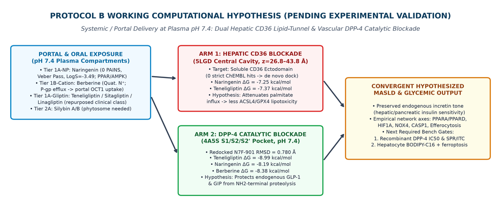

Figure 7. Integrated computational working hypothesis for dual hepatic CD36 tunnel blockade and vascular DPP-4 inhibition.

## 4. References

1. 1. Rinella ME, Lazarus JV, Ratziu V, et al. A multisociety Delphi consensus statement on new fatty liver disease nomenclature. Hepatology. 2023;78(6):1966-1986. doi:10.1097/HEP.0000000000000520
2. 2. Wilding JPH, Batterham RL, Calanna S, et al. Once-weekly semaglutide in adults with overweight or obesity. N Engl J Med. 2021;384(11):989-1002. doi:10.1056/NEJMoa2032183
3. 3. Wilding JPH, Batterham RL, Davies M, et al. Weight regain and cardiometabolic effects after withdrawal of semaglutide: The STEP 1 trial extension. Diabetes Obes Metab. 2022;24(8):1553-1564. doi:10.1111/dom.14725
4. 4. Rada P, González-Rodríguez Á, García-Monzón C, Valverde ÁM. Understanding lipotoxicity in NAFLD pathogenesis: is CD36 a key driver? Cell Death Dis. 2020;11(9):802. doi:10.1038/s41419-020-03003-w
5. 5. Doll S, Proneth B, Tyurina YY, et al. ACSL4 dictates ferroptosis sensitivity by shaping cellular lipid composition. Nat Chem Biol. 2017;13(1):91-98. doi:10.1038/nchembio.2239
6. 6. Hsieh FL, Turner L, Bolla JR, Robinson CV, Lavstsen T, Higgins MK. The structural basis for CD36 binding by the malaria parasite. Nat Commun. 2016;7(1):12837. doi:10.1038/ncomms12837
7. 7. Deacon CF. Physiology and pharmacology of DPP-4 in glucose homeostasis and the treatment of type 2 diabetes. Front Endocrinol. 2019;10:80. doi:10.3389/fendo.2019.00080
8. 8. Sutton JM, Clark DE, Dunsdon SJ, et al. Novel heterocyclic DPP-4 inhibitors for the treatment of type 2 diabetes. Bioorg Med Chem Lett. 2012;22(3):1464-1468. doi:10.1016/j.bmcl.2011.11.054
9. 9. Nabeno M, Akahoshi F, Kishida H, et al. A comparative study of the binding modes of recently launched dipeptidyl peptidase IV inhibitors in the active site. Biochem Biophys Res Commun. 2013;434(2):191-196. doi:10.1016/j.bbrc.2013.03.010
10. 10. Kim D, Wang L, Beconi M, et al. (2R)-4-Oxo-4-[3-(trifluoromethyl)-5,6-dihydro[1,2,4]triazolo[4,3-a]pyrazin-7(8H)-yl]-1-(2,4,5-trifluorophenyl)butan-2-amine: a potent, orally active dipeptidyl peptidase IV inhibitor for the treatment of type 2 diabetes. J Med Chem. 2005;48(1):141-151. doi:10.1021/jm0493156
11. 11. Eckhardt M, Langkopf E, Mark M, et al. 8-(3-(R)-Aminopiperidin-1-yl)-7-but-2-ynyl-3-methyl-1-(4-methyl-quinazolin-2-ylmethyl)-3,7-dihydropurine-2,6-dione (BI 1356), a highly potent, selective, long-acting, and orally bioavailable DPP-4 inhibitor for the treatment of type 2 diabetes. J Med Chem. 2007;50(26):6450-6453. doi:10.1021/jm701280z
12. 12. Bao Y, Wang L, Xu Y, et al. Salvianolic acid B inhibits macrophage uptake of modified low density lipoprotein (mLDL) in a scavenger receptor CD36-dependent manner. Atherosclerosis. 2012;223(1):152-159. doi:10.1016/j.atherosclerosis.2012.05.006
13. 13. Pan G, Wang G, Liu X, et al. The Involvement of P-Glycoprotein in Berberine Absorption. Pharmacol Toxicol. 2002;91(4):193-197. doi:10.1034/j.1600-0773.2002.t01-1-910403.x
14. 14. Nies AT, Herrmann E, Brom M, et al. Vectorial transport of the plant alkaloid berberine by double-transfected cells expressing the human organic cation transporter 1 (OCT1, SLC22A1) and the efflux pump MDR1 P-glycoprotein (ABCB1). Naunyn Schmiedebergs Arch Pharmacol. 2008;376(6):449-461. doi:10.1007/s00210-007-0219-x
15. 15. Méndez-Sánchez N, Dibildox-Martinez M, Sosa-Noguera J, et al. Superior silybin bioavailability of silybin–phosphatidylcholine complex in oily-medium soft-gel capsules versus conventional silymarin tablets in healthy volunteers. BMC Pharmacol Toxicol. 2019;20(1):5. doi:10.1186/s40360-018-0280-8
16. 16. Yang Y, Wu Y, Zou J, et al. Naringenin Attenuates Non-Alcoholic Fatty Liver Disease by Enhancing Energy Expenditure and Regulating Autophagy via AMPK. Front Pharmacol. 2021;12:687095. doi:10.3389/fphar.2021.687095
17. 17. Zdrazil B, Felix E, Hunter F, et al. The ChEMBL Database in 2023: a drug discovery platform spanning multiple bioactivity data types and time periods. Nucleic Acids Res. 2024;52(D1):D1180-D1192. doi:10.1093/nar/gkad1004
18. 18. Buniello A, Suveges D, Cruz-Castillo C, et al. Open Targets Platform: facilitating therapeutic hypotheses building in drug discovery. Nucleic Acids Res. 2025;53(D1):D1467-D1475. doi:10.1093/nar/gkae1128
19. 19. Szklarczyk D, Kirsch R, Koutrouli M, et al. The STRING database in 2023: protein-protein association networks and functional enrichment analyses for any sequenced genome of interest. Nucleic Acids Res. 2023;51(D1):D638-D646. doi:10.1093/nar/gkac1000
20. 20. Trott O, Olson AJ. AutoDock Vina: improving the speed and accuracy of docking with a new scoring function, efficient optimization, and multithreading. J Comput Chem. 2010;31(2):455-461. doi:10.1002/jcc.21334
21. 21. Eberhardt J, Santos-Martins D, Tillack AF, Forli S. AutoDock Vina 1.2.0: new docking methods, expanded force field, and Python bindings. J Chem Inf Model. 2021;61(8):3891-3898. doi:10.1021/acs.jcim.1c00203
22. 22. Kim S, Chen J, Cheng T, et al. PubChem 2025 update. Nucleic Acids Res. 2025;53(D1):D1516-D1525. doi:10.1093/nar/gkae1059
23. 23. Lipinski CA, Lombardo F, Dominy BW, Feeney PJ. Experimental and computational approaches to estimate solubility and permeability in drug discovery and development settings. Adv Drug Deliv Rev. 2001;46(1-3):3-26. doi:10.1016/S0169-409X(00)00129-0
24. 24. Veber DF, Johnson SR, Cheng HY, et al. Molecular properties that influence the oral bioavailability of drug candidates. J Med Chem. 2002;45(12):2615-2623. doi:10.1021/jm020017n
25. 25. Daina A, Zoete V. A BOILED-Egg to predict gastrointestinal absorption and brain penetration of small molecules. ChemMedChem. 2016;11(11):1117-1121. doi:10.1002/cmdc.201600182
26. 26. Delaney JS. ESOL: estimating aqueous solubility directly from molecular structure. J Chem Inf Comput Sci. 2004;44(3):1000-1005. doi:10.1021/ci034243x
27. 27. Baell JB, Holloway GA. New substructure filters for removal of pan assay interference compounds (PAINS) from screening libraries and for their exclusion in bioassays. J Med Chem. 2010;53(7):2719-2740. doi:10.1021/jm901137j
28. 28. Brenk R, Schipani A, James D, et al. Lessons learnt from assembling screening libraries for drug discovery for neglected diseases. ChemMedChem. 2008;3(3):435-444. doi:10.1002/cmdc.200700139
29. 29. Hopkins AL, Keseru GM, Leeson PD, Rees DC, Reynolds CH. The role of ligand efficiency metrics in drug discovery. Nat Rev Drug Discov. 2014;13(2):105-121. doi:10.1038/nrd4163